# Project BookStore - Simulation of a Data Warehouse

Eloy Chang

13 de abril de 2017

# Abstract

We want to simulate a datawarehouse with all the information of a bookstore, the tables to simulate are:

- Inventory (ProductID,BookID,AuthorID,Price)
- Books (BookID,AuthorID,Rating, Price, UnitsBought, UnitsSold)
- Authors (AuthorID,MaxRating,AvgRating,PublishedBooks,UnitsBought,UnitsSold)
- Purchases (TransactionID, Price, ProductID)
- Sales (TransactionID, ProductID, Price, EmployeeID)
- Employees (EmployerID, Transactions, GeneratedProfit)

# Diagram entity - relationship.

This diagram show how the tables are interconected between them

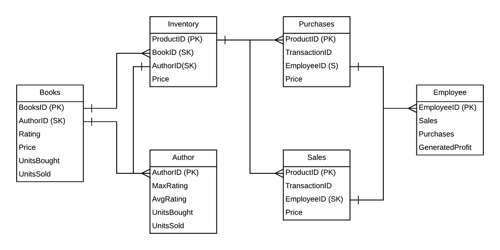

Figure 1 - diagram Entity/Relationship

This diagram was made with the free trial of Lucidchart

# Simulation of tables

Now we wil to simulate the data in this tables, here we must make a important decition, the order to simulate the tables, this change how the simulations will be,

Fisrt lets create the books table.

```r
GenBook<- function(NBooks=100, NAuthors = 20, BasePrice = 10){
    BookID<- 1:NBooks
    AuthorID<- round(runif(NBooks,min = 1, max = NAuthors))
    Rating<- round(rbeta(NBooks,shape1 = 15,shape2 = 10)*5)
    Price<- BasePrice + rgamma(NBooks,shape = BasePrice, scale = 2)
    Price<- Price*(Rating*rnorm(NBooks,mean = 1, sd = 0.1))
    UnitsBought<- round(rgamma(NBooks,shape = 10, scale = 1))*Rating
    UnitsSold<- round(runif(NBooks)*UnitsBought)
    return(data.frame(BookID,AuthorID,Rating,Price,UnitsBought,UnitsSold))
}
Books<- GenBook()
summary(Books)
```

```
##      BookID          AuthorID         Rating         Price
##  Min.   :  1.00   Min.   : 1.00   Min.   :2.00   Min.   : 33.06
##  1st Qu.: 25.75   1st Qu.: 6.00   1st Qu.:3.00   1st Qu.: 67.73
##  Median : 50.50   Median :10.00   Median :3.00   Median : 81.93
##  Mean   : 50.50   Mean   :10.23   Mean   :2.94   Mean   : 86.80
##  3rd Qu.: 75.25   3rd Qu.:15.00   3rd Qu.:3.00   3rd Qu.:106.89
##  Max.   :100.00   Max.   :20.00   Max.   :4.00   Max.   :175.16
##   UnitsBought      UnitsSold
##  Min.   : 6.00   Min.   : 0.00
##  1st Qu.:21.00   1st Qu.: 5.00
##  Median :27.00   Median :12.00
##  Mean   :27.63   Mean   :12.76
##  3rd Qu.:33.75   3rd Qu.:20.00
##  Max.   :57.00   Max.   :41.00
```

The Author table have a direct dependence of the Books table.

```r
GenAuthor<- function(Books){
    N<- max(Books$AuthorID)
    AuthorID<- unique(Books$AuthorID)
    MaxRating<- tapply(Books$Rating,Books$AuthorID,max)
    AvgRating<- tapply(Books$Rating,Books$AuthorID,mean)
    PublishedBooks<- tapply(Books$BookID,Books$AuthorID,length)
    UnitsBought<- tapply(Books$UnitsBought,Books$AuthorID,sum)
    UnitsSold<- tapply(Books$UnitsSold,Books$AuthorID,sum)
    return(data.frame(AuthorID,MaxRating,AvgRating,PublishedBooks,UnitsBought,UnitsSold))
}
Author<- GenAuthor(Books)
summary(Author)
```

```
##     AuthorID       MaxRating      AvgRating     PublishedBooks
##  Min.   : 1.00   Min.   :3.00   Min.   :2.500   Min.   :1.00
##  1st Qu.: 5.75   1st Qu.:3.00   1st Qu.:2.938   1st Qu.:3.75
##  Median :10.50   Median :3.00   Median :3.000   Median :5.00
##  Mean   :10.50   Mean   :3.45   Mean   :2.963   Mean   :5.00
##  3rd Qu.:15.25   3rd Qu.:4.00   3rd Qu.:3.036   3rd Qu.:7.00
##  Max.   :20.00   Max.   :4.00   Max.   :3.250   Max.   :9.00
##   UnitsBought      UnitsSold
##  Min.   :  6.0   Min.   :  3.00
##  1st Qu.:100.5   1st Qu.: 35.75
##  Median :136.5   Median : 65.00
##  Mean   :138.2   Mean   : 63.80
##  3rd Qu.:183.5   3rd Qu.: 75.25
##  Max.   :283.0   Max.   :180.00
```

Now we are going to simulate the inventory table, this one have a dependece of how much of each book are given by UnitsBought and UnitsSold.

```r
GenInventory<- function(Books){
    CopiesByBook<- Books$UnitsBought - Books$UnitsSold
    ProductID<- numeric();BookID<- numeric();AuthorID<- numeric();Price<- numeric()
    PID<- 1
    for(Book in 1:nrow(Books)){
        if(CopiesByBook[Book]==0){
            next
        }
        ProductID<- c(ProductID,PID:(PID+CopiesByBook[Book]-1))
        BookID<- c(BookID,rep(Book,CopiesByBook[Book]))
        AuthorID<- c(AuthorID,rep(Books$AuthorID[Book], CopiesByBook[Book]))
        Price<- c(Price,rep(Books$Price[Book], CopiesByBook[Book]))
        PID<- PID + CopiesByBook[Book]
    }
    return(data.frame(ProductID,BookID,AuthorID,Price))
}
Inventory<- GenInventory(Books)
summary(Inventory)
```

```
##    ProductID          BookID          AuthorID         Price
##  Min.   :   1.0   Min.   :  1.00   Min.   : 1.00   Min.   : 33.06
##  1st Qu.: 372.5   1st Qu.: 24.00   1st Qu.: 5.00   1st Qu.: 71.55
##  Median : 744.0   Median : 46.00   Median : 9.00   Median : 85.93
##  Mean   : 744.0   Mean   : 47.13   Mean   :10.03   Mean   : 92.34
##  3rd Qu.:1115.5   3rd Qu.: 69.00   3rd Qu.:15.00   3rd Qu.:112.87
##  Max.   :1487.0   Max.   :100.00   Max.   :20.00   Max.   :175.16
```

Now lets create the purchase and sales tables, we have one assumption for each table:

- Purchases: All the copies of a same book were bought in just one transaction.
- Sales: In each transaction a random number of book were sold.

```r
GenPurchases<- function(Books, Inventory, NEmployee=5){
    TID<- 1
    PID<- Inventory$ProductID[nrow(Inventory)] + 1
    TransactionID<- numeric()
    ProductID<- numeric()
    EmployeeID<- numeric()
    Price<- numeric()
    rows<- 1
    for(Book in 1:nrow(Books)){
        entries<- rows:(rows + Books$UnitsBought[Book] - 1)
        TransactionID[entries]<- TID
        EmployeeID[entries]<- round(runif(1,min = 0.5,max = 4.99))
        Price[entries]<- Books$Price[Book]
        aux<- Inventory$BookID==Books$BookID[Book]
        if(Books$UnitsSold[Book]!=0){
            ProductID[entries] <- c(Inventory$ProductID[aux],PID:(PID + Books$UnitsSold[Book] - 1))
        }
        else{
            ProductID[entries] <- Inventory$ProductID[aux]
        }
        rows<- rows + Books$UnitsBought[Book]
        TID<- TID + 1
        PID<- PID + Books$UnitsSold[Book]
    }
    return(data.frame(ProductID,TransactionID,EmployeeID,Price))
}
Purchases<- GenPurchases(Books,Inventory)
summary(Purchases)
```

```
##    ProductID      TransactionID     EmployeeID        Price
##  Min.   :   1.0   Min.   :  1.0   Min.   :1.000   Min.   : 33.06
##  1st Qu.: 691.5   1st Qu.: 22.0   1st Qu.:2.000   1st Qu.: 71.49
##  Median :1382.0   Median : 48.0   Median :3.000   Median : 84.80
##  Mean   :1382.0   Mean   : 47.9   Mean   :2.785   Mean   : 89.69
##  3rd Qu.:2072.5   3rd Qu.: 72.0   3rd Qu.:4.000   3rd Qu.:108.52
##  Max.   :2763.0   Max.   :100.0   Max.   :5.000   Max.   :175.16
```

```r
GenSales<- function(Books, Inventory, Purchases, ProfitRate = 1.1){
    TID<- max(Purchases$TransactionID) + 1
    ProductID<- numeric()
    TransactionID<- numeric()
    EmployeeID<- numeric()
    Price<- numeric()
    ProductSold<- which(Purchases$ProductID %in% Inventory$ProductID)
    ready<- FALSE
    while(!ready){
        Items<- round(runif(1,min = 1,max = min(10,length(ProductSold))))
        TransactionID<- c(TransactionID,rep(TID,Items))
        EmployeeID<- c(EmployeeID,rep(round(runif(1,min = 0.5,max = 4.99)),Items))
        Items<- sample(1:length(ProductSold),Items)
        ProductID<- c(ProductID,Purchases$ProductID[ProductSold[Items]])
        Price<- c(Price,Purchases$Price[ProductSold[Items]]*ProfitRate)
        ProductSold<- ProductSold[-Items]
        TID<- TID + 1
        ready<- length(ProductSold) == 0
    }
    return(data.frame(ProductID,TransactionID,EmployeeID,Price))
}
Sales<- GenSales(Books,Inventory,Purchases)
summary(Sales)
```

```
##    ProductID      TransactionID     EmployeeID        Price
##  Min.   :   1.0   Min.   :101.0   Min.   :1.000   Min.   : 36.37
##  1st Qu.: 372.5   1st Qu.:165.0   1st Qu.:2.000   1st Qu.: 78.70
##  Median : 744.0   Median :243.0   Median :3.000   Median : 94.52
##  Mean   : 744.0   Mean   :240.8   Mean   :2.744   Mean   :101.58
##  3rd Qu.:1115.5   3rd Qu.:312.0   3rd Qu.:4.000   3rd Qu.:124.16
##  Max.   :1487.0   Max.   :385.0   Max.   :5.000   Max.   :192.67
```

The employees table is the last, this one is generated from the simulated information of the Purchases and Sales tables.

```r
GenEmployees<- function(Purchases,Sales){
    NEmployees<- length(unique(Purchases$EmployeeID))
    EmployeesID<- 1:NEmployees
    E.Sales<- numeric(length = NEmployees)
    E.Purchases<- numeric(length = NEmployees)
    GeneratedProfit<- numeric(length = NEmployees)
    for(i in 1:NEmployees){
        E.Sales[i]<- length(unique(Sales$TransactionID[Sales$EmployeeID==i]))
        E.Purchases[i]<- length(unique(Purchases$TransactionID[Purchases$EmployeeID==i]))
        GeneratedProfit[i]<- sum(Sales$Price[Sales$EmployeeID==i]) - sum(Purchases$Price[Purchases$EmployeeID==i])
    }
    return(data.frame(EmployeesID,Sales=E.Sales,Purchases=E.Purchases,GeneratedProfit))
}
Employees<- GenEmployees(Purchases,Sales)
Employees
```

```
##   EmployeesID Sales Purchases GeneratedProfit
## 1           1    62        22       -14918.19
## 2           2    71        23       -29154.46
## 3           3    56        20       -19452.10
## 4           4    71        25       -17753.52
## 5           5    25        10       -15498.81
```

# Database update.

Finally the tables are uploaded in a PostgreSQL database.

```r
WriteTables<- function(Books,Author,Inventory,Purchases,Sales,Employees){
    require(RPostgreSQL)
    drv <- dbDriver("PostgreSQL")
    con <- dbConnect(drv, dbname = "epsilon_dl",host = "localhost", port = 5432, user = "Epsilon", password = "123456")
    dbGetQuery(con, "SET search_path TO bookstore")
    dbWriteTable(con, "Books", Books, row.names = FALSE)
    dbWriteTable(con, "Author", Author, row.names = FALSE)
    dbWriteTable(con, "Inventory", Inventory, row.names = FALSE)
    dbWriteTable(con, "Purchases", Purchases, row.names = FALSE)
    dbWriteTable(con, "Sales", Sales, row.names = FALSE)
    dbWriteTable(con, "Employees", Employees, row.names = FALSE)
    dbDisconnect(con)
    dbUnloadDriver(drv)
    return()
}
WriteTables(Books,Author,Inventory,Purchases,Sales,Employees)
```